# Lab 6

Samara Pyfrom

samarap1@umbc.edu

## Intro

In this document, we’re going to compute the [Moran’s I](https://www.statisticshowto.com/morans-i/) for a set of variables tha we downloaded from the ACS.

If the p-value is significant of the Moran’s I, then we interpret the value of the Moran’s I statistic as follows:

- **-1** is perfect clustering of dissimilar values (you can also think of this as perfect dispersion).
- **0** is no autocorrelation (perfect randomness.)
- **+1** indicates perfect clustering of similar values (it’s the opposite of dispersion).

## Setup

See also [mapping with TidyCensus](https://walker-data.com/tidycensus/articles/spatial-data.html).

```r
library(tidycensus)
library(tidyverse)
library(tigris)
library(sf)
library(dplyr)
library(ggplot2)
library(spdep)
library(tmap)
library(RColorBrewer)

options(tigris_class = "sf") # Make sure we're using sf for tigris
options(tigris_use_cache = TRUE) # Make sure we cache
#census_api_key("YOURKEYHERE")
```

## Baltimore Data

Download data for Baltimore on housing, population, and income. See the [Social Explorer Data Dictionary](https://www.socialexplorer.com/data/ACS2021_5yr/metadata/?ds=ACS21_5yr) for more information about these variables.

```r
# This gets the 2021 ACS 5-Year population, race+eth, housing units, and median household income from the ACS
bltmr_tract_20 <- get_acs(geography = "tract",
                           variables = c("pop" = "B03002_001", # Total
                                         "pop_nhwhite" = "B03002_003", # NH White
                                         "pop_nhblack" = "B03002_004", # NH Black
                                         "pop_nhamind" = "B03002_005", # NH Am Ind
                                         "pop_nhasian" = "B03002_006", # NH Asian
                                         "pop_nhhwnpi" = "B03002_007", # NH Hawaiin/PI
                                         "pop_nhother" = "B03002_008", # One Other
                                         "pop_nhtwomr" = "B03002_009", # Two+
                                         "pop_hispltx" = "B03002_012", # Hispanic/Latinx
                                         "hu_total"  = "B25001_001", # Housing Units
                                         "hu_totocc" = "B25003_001", # Housing Units - Occ
                                         "hu_totown" = "B25003_002", # Housing Units - Owner Occ,
                                         "hu_totrnt" = "B25003_003", # Housing Units - Renter Occ,
                                         "mhhi" = "B19013_001"),

                           year = 2021,
                           survey = "acs5",
                           state = c(24),
                           county = c(510),
                           geometry = TRUE,
                           output = "wide")
bltmr_tract_20 <- st_transform(bltmr_tract_20, 3857)
```

With these commands, we problematically, but conveniently, reduce the **race+eth** into 5 categories:

- NH White
- NH Black
- Hisp/Latx
- NH Asian
- NH Multi/Other

The last set of command also computes the number of occupied houses by the total number of housing units to calculate vacancy rate.

```r
# Computes the NH Asian Population
bltmr_tract_20$pop_nhasianXE <-
  bltmr_tract_20$pop_nhasianE + bltmr_tract_20$pop_nhhwnpiE

# Computes the NH "Other" Population
bltmr_tract_20$pop_nhotherXE <-
  bltmr_tract_20$pop_nhamindE + bltmr_tract_20$pop_nhotherE + bltmr_tract_20$pop_nhtwomrE

# Computes vacant housing (need to verify these are the correct values)
bltmr_tract_20$hu_totvacXE <- bltmr_tract_20$hu_totalE - bltmr_tract_20$hu_totoccE
bltmr_tract_20$hu_totvacXE_pct <- bltmr_tract_20$hu_totvacXE/ bltmr_tract_20$hu_totalE

# Replace NaNs with 0
bltmr_tract_20$hu_totvacXE_pct[is.nan(bltmr_tract_20$hu_totvacXE_pct)] <- 0
bltmr_tract_20$hu_totvacXE_pct <- as.numeric(bltmr_tract_20$hu_totvacXE_pct)
```

# Analyze Vacancy

See [this example](https://mgimond.github.io/simple_moransI_example/).

Let’s just take a look at the distribution of vacancy rates.

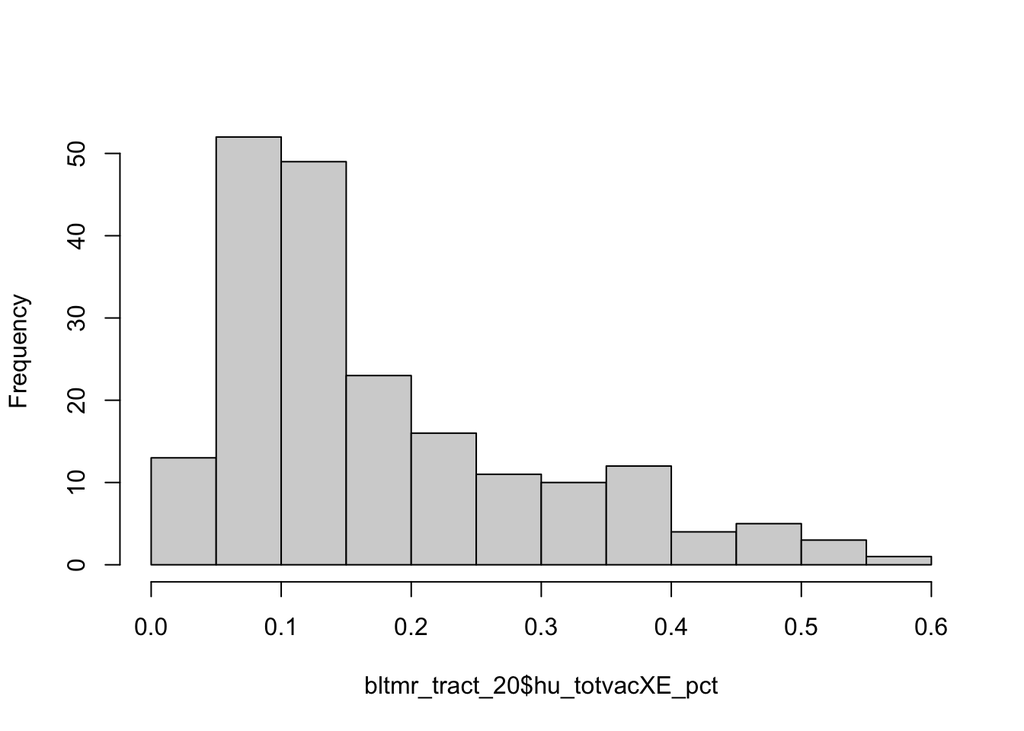

```r
hist(bltmr_tract_20$hu_totvacXE_pct, main=NULL)
```

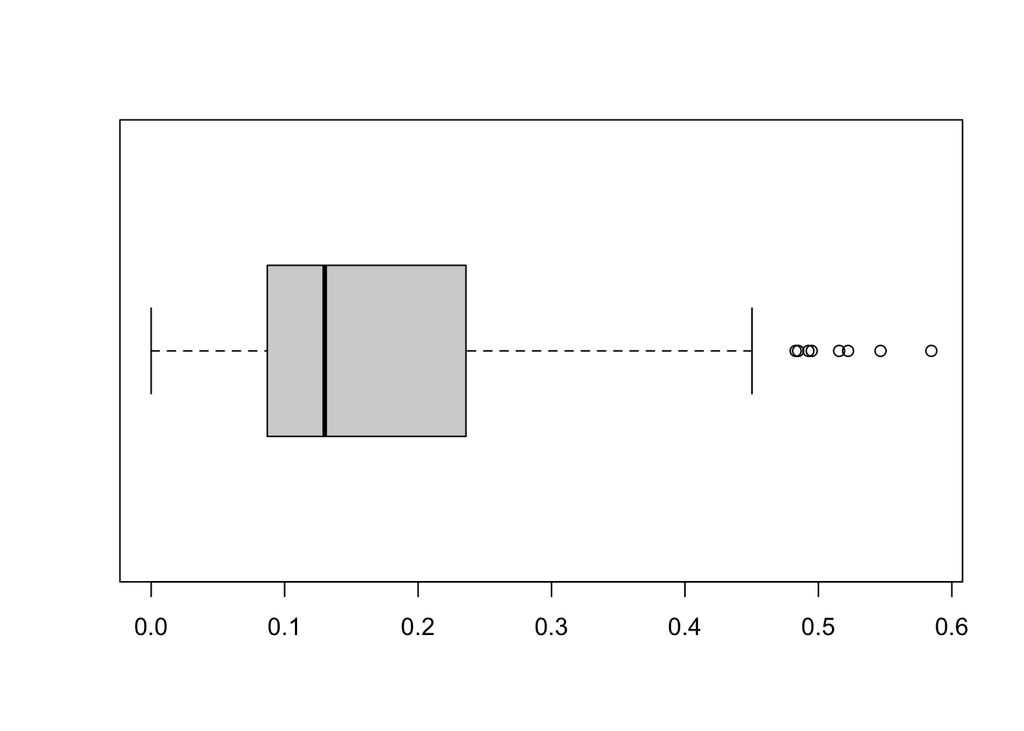

```r
boxplot(bltmr_tract_20$hu_totvacXE_pct, horizontal = TRUE)
```

Quick map using `tmap` library. Feel free to use use `ggplot2`.

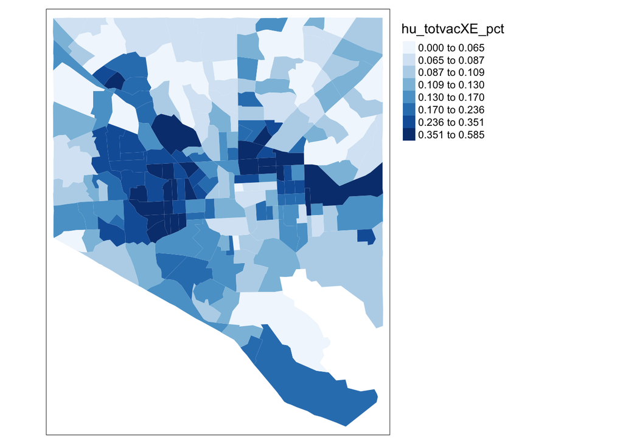

```r
tm_shape(bltmr_tract_20) + tm_fill(col="hu_totvacXE_pct", style="quantile", n=8, palette="Blues") +
              tm_legend(outside=TRUE)
```

Create a matrix of neighboring (adjacent) polygons for each tract. The `poly2nb` function creates a list of [adjacent polygons](https://www.rdocumentation.org/packages/spdep/versions/1.2-7/topics/poly2nb) for each polygon. Then `nb2listw` puts this list in a [spatial weights format](https://www.rdocumentation.org/packages/spdep/versions/1.2-7/topics/nb2listw) that we need for the Moran’s I.

```r
bltmr_tract_nb  <- poly2nb(bltmr_tract_20, queen=TRUE) # creates neighbor/adjacency list
bltmr_tract_lw  <- nb2listw(bltmr_tract_nb, style="W", zero.policy=TRUE) # puts in a listw format
```

Compute Moran’s I.

```r
# compute Moran's I on vacancy and store in a variable, notice the listw input
bltmr_tract_moran.vac <- moran.test(bltmr_tract_20$hu_totvacXE_pct, bltmr_tract_lw)

# show the Moran's I output
bltmr_tract_moran.vac
```

```
##
##  Moran I test under randomisation
##
## data:  bltmr_tract_20$hu_totvacXE_pct
## weights: bltmr_tract_lw
##
## Moran I statistic standard deviate = 14.501, p-value < 2.2e-16
## alternative hypothesis: greater
## sample estimates:
## Moran I statistic       Expectation          Variance
##       0.588653172      -0.005050505       0.001676239
```

```r
# replace NA with 0 for median household income - a better solution might be to remove them before computing the poly2nb or the nb2listw
bltmr_tract_20$mhhiE[is.na(bltmr_tract_20$mhhiE)] <- 0

# compute Moran's I and store in a variable
bltmr_tract_moran.mhhi <- moran.test(bltmr_tract_20$mhhiE, bltmr_tract_lw)

# show the Moran's I output
bltmr_tract_moran.mhhi
```

```
##
##  Moran I test under randomisation
##
## data:  bltmr_tract_20$mhhiE
## weights: bltmr_tract_lw
##
## Moran I statistic standard deviate = 12.447, p-value < 2.2e-16
## alternative hypothesis: greater
## sample estimates:
## Moran I statistic       Expectation          Variance
##       0.500345629      -0.005050505       0.001648545
```

## Using the data

Here we make a grid, note the piping to make it an `sf` object.

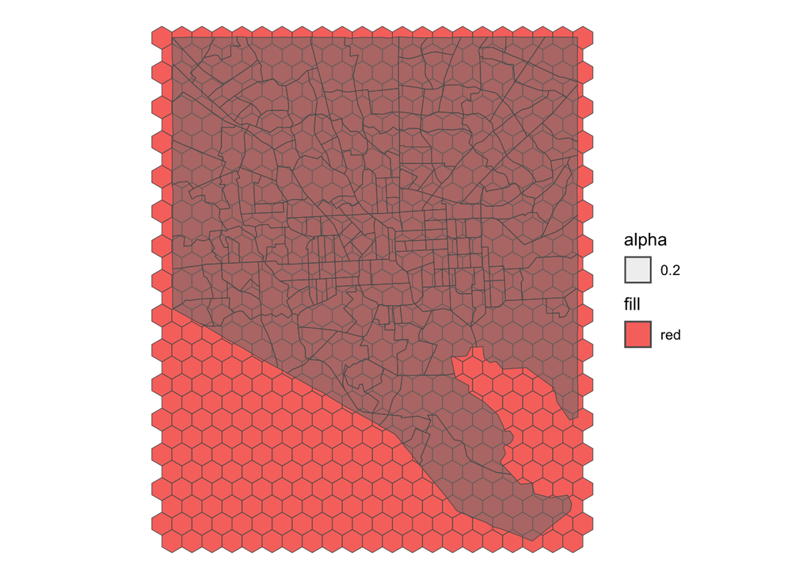

```r
# 3857 is in meters, so this is 1km
bltmr_hex <- st_make_grid(bltmr_tract_20,
  1 * 1000,
  crs = st_crs(bltmr_tract_20),
  what = "polygons",
  square = FALSE) %>%
  st_sf %>% # make an sf object
  st_cast # make polygons


# create an ID for each row
#bltmr_hex$GEOID <- 0 # this forces it to be a number, sets all values to 0
bltmr_hex$GEOID <- seq.int(nrow(bltmr_hex))

ggplot() + geom_sf(data=bltmr_hex, aes(fill="red")) +
  geom_sf(data=bltmr_tract_20, aes(fill = NA, alpha = 0.2)) +
  theme_void()
```

We can spatially subset (filter or intersect) this grid to what overlaps the city (or specifically the tracts of the city).

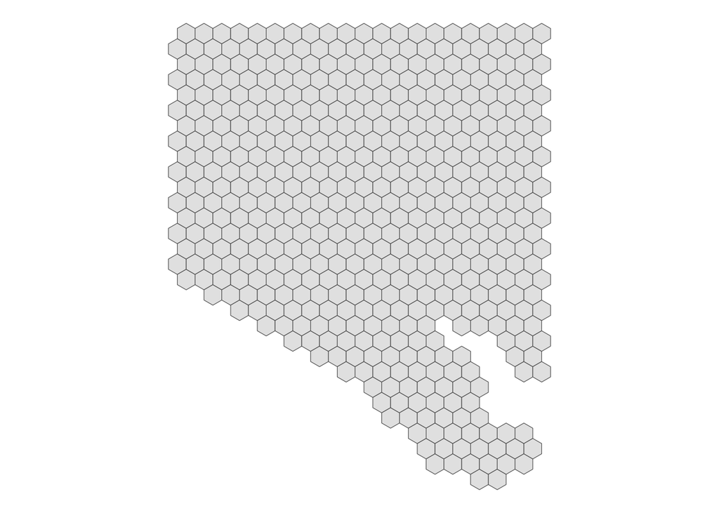

```r
bltmr_hex_20 <- st_filter(bltmr_hex, bltmr_tract_20, .predicate=st_intersects)

ggplot() + geom_sf(data=bltmr_hex_20, aes()) + theme_void()
```

Now we’re going to area weight median household income into the hexagons.

```r
# overwriting this variable
bltmr_hex_20.mhhi <- st_interpolate_aw(bltmr_tract_20["mhhiE"], bltmr_hex_20, extensive = FALSE)
```

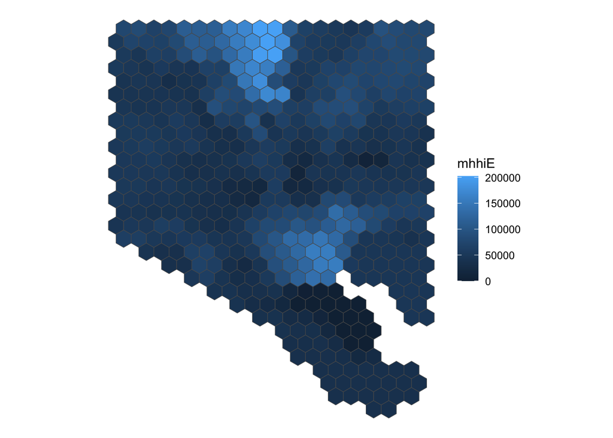

```r
ggplot() +
  geom_sf(data=bltmr_hex_20.mhhi, aes(fill = mhhiE)) +
  theme_void()
```

## Exercises

1. Compute the area weight for a) percent white and b) vacancy rates using hexagons.

```r
# Percent white calculation
bltmr_tract_20$pct_nhwhite <-
  bltmr_tract_20$pop_nhwhiteE / bltmr_tract_20$popE
# Vacant Housing calculation
bltmr_tract_20$hu_totvacXE <- bltmr_tract_20$hu_totalE -
  bltmr_tract_20$hu_totoccE
bltmr_tract_20$hu_totvacXE_pct <-
  bltmr_tract_20$hu_totvacXE/bltmr_tract_20$hu_totalE
#replace na with 0
bltmr_tract_20$hu_totvacXE_pct[is.nan(bltmr_tract_20$hu_totvacXE_pct)] <- 0
bltmr_tract_20$hu_totvacXE_pct <- as.numeric(bltmr_tract_20$hu_totvacXE_pct)
```

2. Create quick map of both.

```r
#percent white
bltmr_hex_20.pct_nhwhite <-
  st_interpolate_aw(bltmr_tract_20["pct_nhwhite"],
                    bltmr_hex_20, extensive = FALSE)
```

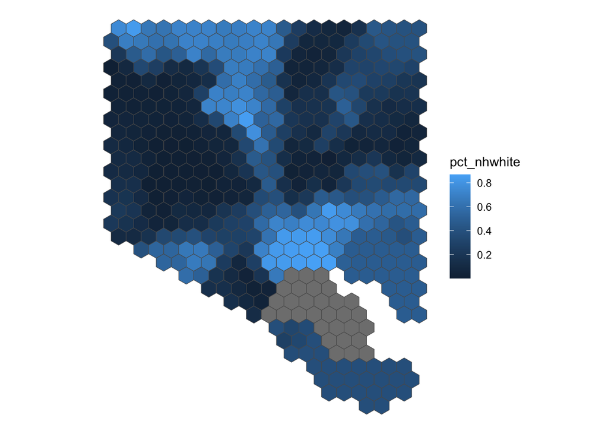

```r
ggplot()+
  geom_sf(data=bltmr_hex_20.pct_nhwhite, aes(fill= pct_nhwhite)) +
  theme_void()
```

```r
st_write(bltmr_hex_20.pct_nhwhite, paste0(tempdir(), "/",
                                          "bltmr_hex_20.pct_nhwhite.geojson"))
```

```
## Writing layer `bltmr_hex_20.pct_nhwhite' to data source
##   `/var/folders/w4/4yw7sz2d6nx1l9fj1b47ft4w0000gn/T//RtmpVV9L56/bltmr_hex_20.pct_nhwhite.geojson' using driver `GeoJSON'
## Writing 483 features with 1 fields and geometry type Polygon.
```

```r
# Moran's I computation
bltmr_tract_20$pct_nhwhite[is.na(bltmr_tract_20$pct_nhwhite)] <-0
bltmr_tract_moran.pct_nhwhite <- moran.test(bltmr_tract_20$pct_nhwhite,
                                            bltmr_tract_lw)
bltmr_tract_moran.pct_nhwhite
```

```
##
##  Moran I test under randomisation
##
## data:  bltmr_tract_20$pct_nhwhite
## weights: bltmr_tract_lw
##
## Moran I statistic standard deviate = 15.189, p-value < 2.2e-16
## alternative hypothesis: greater
## sample estimates:
## Moran I statistic       Expectation          Variance
##       0.618758238      -0.005050505       0.001686749
```

```r
bltmr_hex_20.hu_totvacXE_pct <-
st_interpolate_aw(bltmr_tract_20["hu_totvacXE_pct"],
bltmr_hex_20, extensive = FALSE)
```

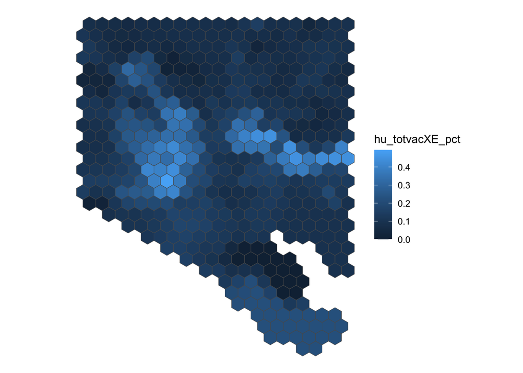

```r
ggplot() +
geom_sf(data=bltmr_hex_20.hu_totvacXE_pct, aes(fill = hu_totvacXE_pct)) +
theme_void()
```

```r
#export
#st_write(bltmr_hex_20.mhhi,"bltmr_hex_20.mhhi.geojson")
#white map
#st_write(bltmr_hex_20.pct_nhwhite, "bltmr_hex_20.pct.nhwhite.geojson")
#total vacancy
#st_write(bltmr_hex_20.hu_totvacXE_pct, "bltmr_hex_20.hu_totvacXE_pct.geojson")
```

```r
#st_write(bltmr_hex_20.hu_totvacXE_pct, "bltmr_hex_20.hu_totvacXE_pct.geojson")
```

4. Export the three variables as shapefiles using [`st_write`](https://r-spatial.github.io/sf/reference/st_write.html). I recommend using files with the extension of “.geojson” to make things easier to import into QGIS …
5. Make set of polished maps in QGIS using the layout manager.